# Trade&Ahead Presentation Notebook

## Problem Statement

Description Context The stock market has consistently proven to be a good place to invest in and save for the future. There are a lot of compelling reasons to invest in stocks. It can help in fighting inflation, create wealth, and also provides some tax benefits. Good steady returns on investments over a long period of time can also grow a lot more than seems possible. Also, thanks to the power of compound interest, the earlier one starts investing, the larger the corpus one can have for retirement. Overall, investing in stocks can help meet life's financial aspirations.

It is important to maintain a diversified portfolio when investing in stocks in order to maximize earnings under any market condition. Having a diversified portfolio tends to yield higher returns and face lower risk by tempering potential losses when the market is down. It is often easy to get lost in a sea of financial metrics to analyze while determining the worth of a stock, and doing the same for a multitude of stocks to identify the right picks for an individual can be a tedious task. By doing a cluster analysis, one can identify stocks that exhibit similar characteristics and ones that exhibit minimum correlation. This will help investors better analyze stocks across different market segments and help protect against risks that could make the portfolio vulnerable to losses.

Objective Trade&Ahead is a financial consultancy firm who provide their customers with personalized investment strategies. They have hired you as a Data Scientist and provided you with data comprising stock price and some financial indicators for a few companies listed under the New York Stock Exchange. They have assigned you the tasks of analyzing the data, grouping the stocks based on the attributes provided, and sharing insights about the characteristics of each group.

Data Description The data provided is of stock prices and some financial indicators like ROE, earnings per share, P/E ratio, etc.

Data Dictionary

Ticker Symbol: An abbreviation used to uniquely identify publicly traded shares of a particular stock on a particular stock market Company: Name of the company GICS Sector: The specific economic sector assigned to a company by the Global Industry Classification Standard (GICS) that best defines its business operations GICS Sub Industry: The specific sub-industry group assigned to a company by the Global Industry Classification Standard (GICS) that best defines its business operations Current Price: Current stock price in dollars Price Change: Percentage change in the stock price in 13 weeks Volatility: Standard deviation of the stock price over the past 13 weeks ROE: A measure of financial performance calculated by dividing net income by shareholders' equity (shareholders' equity is equal to a company's assets minus its debt) Cash Ratio: The ratio of a company's total reserves of cash and cash equivalents to its total current liabilities Net Cash Flow: The difference between a company's cash inflows and outflows (in dollars) Net Income: Revenues minus expenses, interest, and taxes (in dollars) Earnings Per Share: Company's net profit divided by the number of common shares it has outstanding (in dollars) Estimated Shares Outstanding: Company's stock currently held by all its shareholders P/E Ratio: Ratio of the company's current stock price to the earnings per share P/B Ratio: Ratio of the company's stock price per share by its book value per share (book value of a company is the net difference between that company's total assets and total liabilities)

## Importing necessary libraries and data

```python
# this will help in making the Python code more structured automatically (good coding practice)
%reload_ext nb_black

# Libraries to help with reading and manipulating data
import numpy as np
import pandas as pd

# Libraries to help with data visualization
import matplotlib.pyplot as plt
import seaborn as sns

# to scale the data using z-score
from sklearn.preprocessing import StandardScaler

# to compute distances
from scipy.spatial.distance import cdist

# to perform k-means clustering and compute silhouette scores
from sklearn.cluster import KMeans
from sklearn.metrics import silhouette_score

# to visualize the elbow curve and silhouette scores
from yellowbrick.cluster import KElbowVisualizer, SilhouetteVisualizer

# Removes the limit for the number of displayed columns
pd.set_option("display.max_columns", None)
# Sets the limit for the number of displayed rows
pd.set_option("display.max_rows", 200)


# to perform hierarchical clustering, compute cophenetic correlation, and create dendrograms
from sklearn.cluster import AgglomerativeClustering
from scipy.cluster.hierarchy import dendrogram, linkage, cophenet

# to perform PCA
from sklearn.decomposition import PCA

# to compute distances
from scipy.spatial.distance import pdist
```

```python
import warnings

warnings.filterwarnings("ignore")
```

```python
# import data file
data = pd.read_csv("stock_data.csv")
```

## Data Overview

- Observations
- Sanity checks

```python
data.shape
```

```
(340, 15)
```

- data has 340 rows and 15 columns

```python
#check what the data looks like
data.head()
```

|  | Ticker Symbol | Security | GICS Sector | GICS Sub Industry | Current Price | Price Change | Volatility | ROE | Cash Ratio | Net Cash Flow | Net Income | Earnings Per Share | Estimated Shares Outstanding | P/E Ratio | P/B Ratio |
| --- | --- | --- | --- | --- | --- | --- | --- | --- | --- | --- | --- | --- | --- | --- | --- |
| 0 | AAL | American Airlines Group | Industrials | Airlines | 42.349998 | 9.999995 | 1.687151 | 135 | 51 | -604000000 | 7610000000 | 11.39 | 6.681299e+08 | 3.718174 | -8.784219 |
| 1 | ABBV | AbbVie | Health Care | Pharmaceuticals | 59.240002 | 8.339433 | 2.197887 | 130 | 77 | 51000000 | 5144000000 | 3.15 | 1.633016e+09 | 18.806350 | -8.750068 |
| 2 | ABT | Abbott Laboratories | Health Care | Health Care Equipment | 44.910000 | 11.301121 | 1.273646 | 21 | 67 | 938000000 | 4423000000 | 2.94 | 1.504422e+09 | 15.275510 | -0.394171 |
| 3 | ADBE | Adobe Systems Inc | Information Technology | Application Software | 93.940002 | 13.977195 | 1.357679 | 9 | 180 | -240840000 | 629551000 | 1.26 | 4.996437e+08 | 74.555557 | 4.199651 |
| 4 | ADI | Analog Devices, Inc. | Information Technology | Semiconductors | 55.320000 | -1.827858 | 1.701169 | 14 | 272 | 315120000 | 696878000 | 0.31 | 2.247994e+09 | 178.451613 | 1.059810 |

- data is made up of a lot of different types

```python
# information on numerical columns
data.describe()
```

|  | Current Price | Price Change | Volatility | ROE | Cash Ratio | Net Cash Flow | Net Income | Earnings Per Share | Estimated Shares Outstanding | P/E Ratio | P/B Ratio |
| --- | --- | --- | --- | --- | --- | --- | --- | --- | --- | --- | --- |
| count | 340.000000 | 340.000000 | 340.000000 | 340.000000 | 340.000000 | 3.400000e+02 | 3.400000e+02 | 340.000000 | 3.400000e+02 | 340.000000 | 340.000000 |
| mean | 80.862345 | 4.078194 | 1.525976 | 39.597059 | 70.023529 | 5.553762e+07 | 1.494385e+09 | 2.776662 | 5.770283e+08 | 32.612563 | -1.718249 |
| std | 98.055086 | 12.006338 | 0.591798 | 96.547538 | 90.421331 | 1.946365e+09 | 3.940150e+09 | 6.587779 | 8.458496e+08 | 44.348731 | 13.966912 |
| min | 4.500000 | -47.129693 | 0.733163 | 1.000000 | 0.000000 | -1.120800e+10 | -2.352800e+10 | -61.200000 | 2.767216e+07 | 2.935451 | -76.119077 |
| 25% | 38.555000 | -0.939484 | 1.134878 | 9.750000 | 18.000000 | -1.939065e+08 | 3.523012e+08 | 1.557500 | 1.588482e+08 | 15.044653 | -4.352056 |
| 50% | 59.705000 | 4.819505 | 1.385593 | 15.000000 | 47.000000 | 2.098000e+06 | 7.073360e+08 | 2.895000 | 3.096751e+08 | 20.819876 | -1.067170 |
| 75% | 92.880001 | 10.695493 | 1.695549 | 27.000000 | 99.000000 | 1.698108e+08 | 1.899000e+09 | 4.620000 | 5.731175e+08 | 31.764755 | 3.917066 |
| max | 1274.949951 | 55.051683 | 4.580042 | 917.000000 | 958.000000 | 2.076400e+10 | 2.444200e+10 | 50.090000 | 6.159292e+09 | 528.039074 | 129.064585 |

- values range from negative values up to ^10

```python
data.info()
```

```
<class 'pandas.core.frame.DataFrame'>
RangeIndex: 340 entries, 0 to 339
Data columns (total 15 columns):
 #   Column                        Non-Null Count  Dtype
---  ------                        --------------  -----
 0   Ticker Symbol                 340 non-null    object
 1   Security                      340 non-null    object
 2   GICS Sector                   340 non-null    object
 3   GICS Sub Industry             340 non-null    object
 4   Current Price                 340 non-null    float64
 5   Price Change                  340 non-null    float64
 6   Volatility                    340 non-null    float64
 7   ROE                           340 non-null    int64
 8   Cash Ratio                    340 non-null    int64
 9   Net Cash Flow                 340 non-null    int64
 10  Net Income                    340 non-null    int64
 11  Earnings Per Share            340 non-null    float64
 12  Estimated Shares Outstanding  340 non-null    float64
 13  P/E Ratio                     340 non-null    float64
 14  P/B Ratio                     340 non-null    float64
dtypes: float64(7), int64(4), object(4)
memory usage: 40.0+ KB
```

- 4 of the 15 columns are onject type, with the rest numbers consisting of floats and integers.
- no missing values in data set

## Data Preprocessing

- Duplicate value check
- Missing value treatment
- Outlier check
- Feature engineering (if needed)
- Any other preprocessing steps (if needed)

```python
# double check no missing values
data.isna().sum()
```

```
Ticker Symbol                   0
Security                        0
GICS Sector                     0
GICS Sub Industry               0
Current Price                   0
Price Change                    0
Volatility                      0
ROE                             0
Cash Ratio                      0
Net Cash Flow                   0
Net Income                      0
Earnings Per Share              0
Estimated Shares Outstanding    0
P/E Ratio                       0
P/B Ratio                       0
dtype: int64
```

- double check shows no missing values (n/a)

```python
data.describe(include="all").T
```

|  | count | unique | top | freq | mean | std | min | 25% | 50% | 75% | max |
| --- | --- | --- | --- | --- | --- | --- | --- | --- | --- | --- | --- |
| Ticker Symbol | 340 | 340 | GT | 1 | NaN | NaN | NaN | NaN | NaN | NaN | NaN |
| Security | 340 | 340 | Teradata Corp. | 1 | NaN | NaN | NaN | NaN | NaN | NaN | NaN |
| GICS Sector | 340 | 11 | Industrials | 53 | NaN | NaN | NaN | NaN | NaN | NaN | NaN |
| GICS Sub Industry | 340 | 104 | Oil & Gas Exploration & Production | 16 | NaN | NaN | NaN | NaN | NaN | NaN | NaN |
| Current Price | 340 | NaN | NaN | NaN | 80.8623 | 98.0551 | 4.5 | 38.555 | 59.705 | 92.88 | 1274.95 |
| Price Change | 340 | NaN | NaN | NaN | 4.07819 | 12.0063 | -47.1297 | -0.939484 | 4.8195 | 10.6955 | 55.0517 |
| Volatility | 340 | NaN | NaN | NaN | 1.52598 | 0.591798 | 0.733163 | 1.13488 | 1.38559 | 1.69555 | 4.58004 |
| ROE | 340 | NaN | NaN | NaN | 39.5971 | 96.5475 | 1 | 9.75 | 15 | 27 | 917 |
| Cash Ratio | 340 | NaN | NaN | NaN | 70.0235 | 90.4213 | 0 | 18 | 47 | 99 | 958 |
| Net Cash Flow | 340 | NaN | NaN | NaN | 5.55376e+07 | 1.94637e+09 | -1.1208e+10 | -1.93906e+08 | 2.098e+06 | 1.69811e+08 | 2.0764e+10 |
| Net Income | 340 | NaN | NaN | NaN | 1.49438e+09 | 3.94015e+09 | -2.3528e+10 | 3.52301e+08 | 7.07336e+08 | 1.899e+09 | 2.4442e+10 |
| Earnings Per Share | 340 | NaN | NaN | NaN | 2.77666 | 6.58778 | -61.2 | 1.5575 | 2.895 | 4.62 | 50.09 |
| Estimated Shares Outstanding | 340 | NaN | NaN | NaN | 5.77028e+08 | 8.4585e+08 | 2.76722e+07 | 1.58848e+08 | 3.09675e+08 | 5.73117e+08 | 6.15929e+09 |
| P/E Ratio | 340 | NaN | NaN | NaN | 32.6126 | 44.3487 | 2.93545 | 15.0447 | 20.8199 | 31.7648 | 528.039 |
| P/B Ratio | 340 | NaN | NaN | NaN | -1.71825 | 13.9669 | -76.1191 | -4.35206 | -1.06717 | 3.91707 | 129.065 |

```python
# make a copy of data to make sure nothing is affected going forward
df = data.copy()
```

```python
# Let's see unique values
cols = df.columns

for col in cols:
    print("Unique values in the column '{}' are \n\n".format(col), df[col].unique())
    print("-" * 100)
```

```
Unique values in the column 'Ticker Symbol' are

 ['AAL' 'ABBV' 'ABT' 'ADBE' 'ADI' 'ADM' 'ADS' 'AEE' 'AEP' 'AFL' 'AIG' 'AIV'
 'AIZ' 'AJG' 'AKAM' 'ALB' 'ALK' 'ALL' 'ALLE' 'ALXN' 'AMAT' 'AME' 'AMG'
 'AMGN' 'AMP' 'AMT' 'AMZN' 'AN' 'ANTM' 'AON' 'APA' 'APC' 'APH' 'ARNC'
 'ATVI' 'AVB' 'AVGO' 'AWK' 'AXP' 'BA' 'BAC' 'BAX' 'BBT' 'BCR' 'BHI' 'BIIB'
 'BK' 'BLL' 'BMY' 'BSX' 'BWA' 'BXP' 'C' 'CAT' 'CB' 'CBG' 'CCI' 'CCL'
 'CELG' 'CF' 'CFG' 'CHD' 'CHK' 'CHRW' 'CHTR' 'CI' 'CINF' 'CL' 'CMA' 'CME'
 'CMG' 'CMI' 'CMS' 'CNC' 'CNP' 'COF' 'COG' 'COO' 'CSX' 'CTL' 'CTSH' 'CTXS'
 'CVS' 'CVX' 'CXO' 'D' 'DAL' 'DD' 'DE' 'DFS' 'DGX' 'DHR' 'DIS' 'DISCA'
 'DISCK' 'DLPH' 'DLR' 'DNB' 'DOV' 'DPS' 'DUK' 'DVA' 'DVN' 'EBAY' 'ECL'
 'ED' 'EFX' 'EIX' 'EMN' 'EOG' 'EQIX' 'EQR' 'EQT' 'ES' 'ESS' 'ETFC' 'ETN'
 'ETR' 'EW' 'EXC' 'EXPD' 'EXPE' 'EXR' 'F' 'FAST' 'FB' 'FBHS' 'FCX' 'FE'
 'FIS' 'FISV' 'FLIR' 'FLR' 'FLS' 'FMC' 'FRT' 'FSLR' 'FTR' 'GD' 'GGP'
 'GILD' 'GLW' 'GM' 'GPC' 'GRMN' 'GT' 'GWW' 'HAL' 'HAS' 'HBAN' 'HCA' 'HCN'
 'HCP' 'HES' 'HIG' 'HOG' 'HON' 'HPE' 'HPQ' 'HRL' 'HSIC' 'HST' 'HSY' 'HUM'
 'IBM' 'IDXX' 'IFF' 'INTC' 'IP' 'IPG' 'IRM' 'ISRG' 'ITW' 'IVZ' 'JBHT'
 'JEC' 'JNPR' 'JPM' 'KIM' 'KMB' 'KMI' 'KO' 'KSU' 'LEG' 'LEN' 'LH' 'LKQ'
 'LLL' 'LLY' 'LMT' 'LNT' 'LUK' 'LUV' 'LVLT' 'LYB' 'MA' 'MAA' 'MAC' 'MAR'
 'MAS' 'MAT' 'MCD' 'MCO' 'MDLZ' 'MET' 'MHK' 'MJN' 'MKC' 'MLM' 'MMC' 'MMM'
 'MNST' 'MO' 'MOS' 'MPC' 'MRK' 'MRO' 'MTB' 'MTD' 'MUR' 'MYL' 'NAVI' 'NBL'
 'NDAQ' 'NEE' 'NEM' 'NFLX' 'NFX' 'NLSN' 'NOV' 'NSC' 'NTRS' 'NUE' 'NWL' 'O'
 'OKE' 'OMC' 'ORLY' 'OXY' 'PBCT' 'PBI' 'PCAR' 'PCG' 'PCLN' 'PEG' 'PEP'
 'PFE' 'PFG' 'PG' 'PGR' 'PHM' 'PM' 'PNC' 'PNR' 'PNW' 'PPG' 'PPL' 'PRU'
 'PSX' 'PWR' 'PX' 'PYPL' 'R' 'RCL' 'REGN' 'RHI' 'ROP' 'RRC' 'RSG' 'SCG'
 'SCHW' 'SE' 'SEE' 'SHW' 'SLG' 'SNI' 'SO' 'SPG' 'SPGI' 'SRCL' 'SRE' 'STI'
 'STT' 'SWKS' 'SWN' 'SYF' 'SYK' 'T' 'TAP' 'TDC' 'TGNA' 'TMK' 'TMO' 'TRIP'
 'TRV' 'TSCO' 'TSN' 'TSO' 'TSS' 'TXN' 'UAA' 'UAL' 'UDR' 'UHS' 'UNH' 'UNM'
 'UNP' 'UPS' 'UTX' 'VAR' 'VLO' 'VMC' 'VNO' 'VRSK' 'VRSN' 'VRTX' 'VTR' 'VZ'
 'WAT' 'WEC' 'WFC' 'WHR' 'WM' 'WMB' 'WU' 'WY' 'WYN' 'WYNN' 'XEC' 'XEL'
 'XL' 'XOM' 'XRAY' 'XRX' 'XYL' 'YHOO' 'YUM' 'ZBH' 'ZION' 'ZTS']
----------------------------------------------------------------------------------------------------
Unique values in the column 'Security' are

 ['American Airlines Group' 'AbbVie' 'Abbott Laboratories'
 'Adobe Systems Inc' 'Analog Devices, Inc.' 'Archer-Daniels-Midland Co'
 'Alliance Data Systems' 'Ameren Corp' 'American Electric Power'
 'AFLAC Inc' 'American International Group, Inc.'
 'Apartment Investment & Mgmt' 'Assurant Inc' 'Arthur J. Gallagher & Co.'
 'Akamai Technologies Inc' 'Albemarle Corp' 'Alaska Air Group Inc'
```

[output cut: 772 more lines]

[output not shown]

## Exploratory Data Analysis (EDA)

- EDA is an important part of any project involving data.
- It is important to investigate and understand the data better before building a model with it.
- A few questions have been mentioned below which will help you approach the analysis in the right manner and generate insights from the data.
- A thorough analysis of the data, in addition to the questions mentioned below, should be done.

**Questions**:

1. What does the distribution of stock prices look like?
2. The stocks of which economic sector have seen the maximum price increase on average?
3. How are the different variables correlated with each other?
4. Cash ratio provides a measure of a company's ability to cover its short-term obligations using only cash and cash equivalents. How does the average cash ratio vary across economic sectors?
5. P/E ratios can help determine the relative value of a company's shares as they signify the amount of money an investor is willing to invest in a single share of a company per dollar of its earnings. How does the P/E ratio vary, on average, across economic sectors?

```python
# function to plot a boxplot and a histogram along the same scale.


def histogram_boxplot(data, feature, figsize=(12, 7), kde=False, bins=None):
    """
    Boxplot and histogram combined

    data: dataframe
    feature: dataframe column
    figsize: size of figure (default (12,7))
    kde: whether to the show density curve (default False)
    bins: number of bins for histogram (default None)
    """
    f2, (ax_box2, ax_hist2) = plt.subplots(
        nrows=2,  # Number of rows of the subplot grid= 2
        sharex=True,  # x-axis will be shared among all subplots
        gridspec_kw={"height_ratios": (0.25, 0.75)},
        figsize=figsize,
    )  # creating the 2 subplots
    sns.boxplot(
        data=data, x=feature, ax=ax_box2, showmeans=True, color="violet"
    )  # boxplot will be created and a star will indicate the mean value of the column
    sns.histplot(
        data=data, x=feature, kde=kde, ax=ax_hist2, bins=bins, palette="winter"
    ) if bins else sns.histplot(
        data=data, x=feature, kde=kde, ax=ax_hist2
    )  # For histogram
    ax_hist2.axvline(
        data[feature].mean(), color="green", linestyle="--"
    )  # Add mean to the histogram
    ax_hist2.axvline(
        data[feature].median(), color="black", linestyle="-"
    )  # Add median to the histogram
```

#### Distribution of Numerical Columns

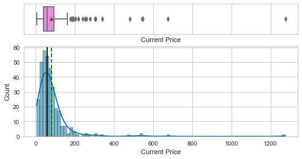

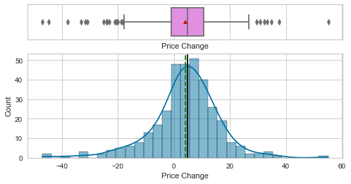

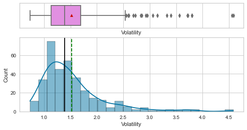

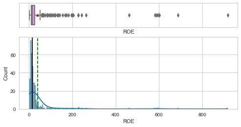

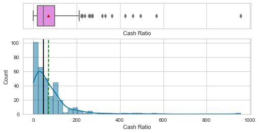

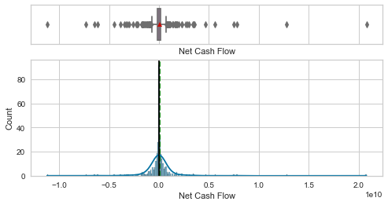

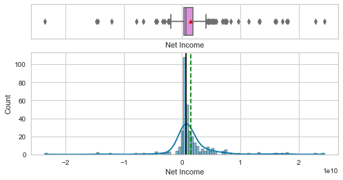

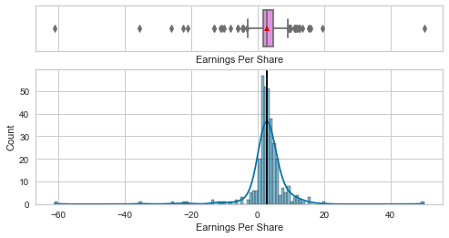

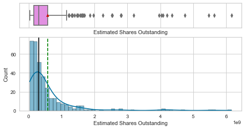

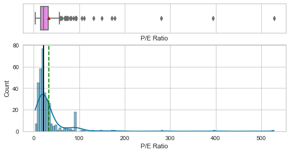

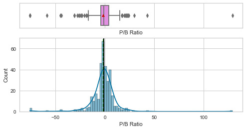

```python
# selecting numerical columns
num_col = df.select_dtypes(include=np.number).columns.tolist()

for item in num_col:
    histogram_boxplot(df, item, kde=True, figsize=(8, 4))
```

- All of the numerical columns exhibit bell shaped curves in some form or another.
- As a lot of these columns deal with large amounts of money there is a very wide range of minimums and maximums.
- All of the columns are affected by outliers

#### What does the distribution of Stock Price look like?

```python
df["Current Price"].describe()
```

```
count     340.000000
mean       80.862345
std        98.055086
min         4.500000
25%        38.555000
50%        59.705000
75%        92.880001
max      1274.949951
Name: Current Price, dtype: float64
```

- Stock prices range from 4.5 to 1274.95 US dollars with an average of 80.86 US dollars
- Very heavily skewed curve

### Bivariate Analysis

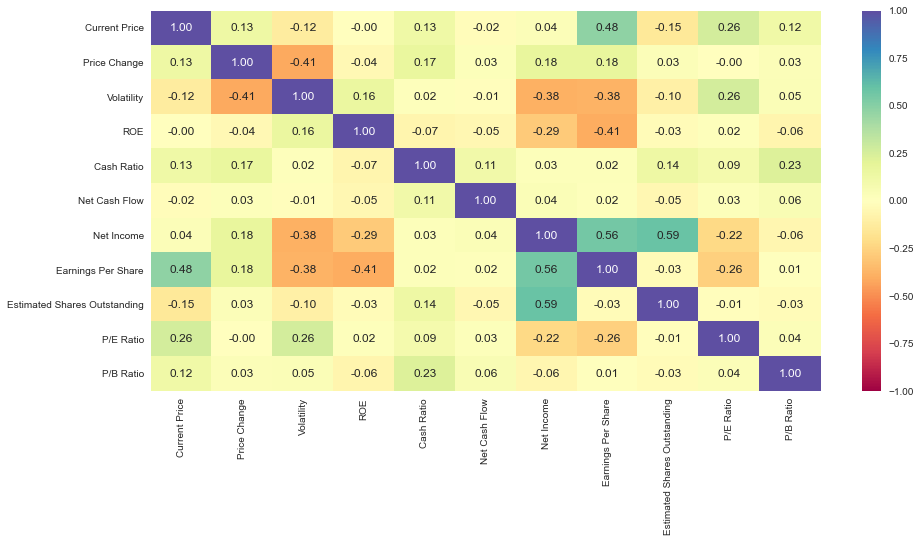

```python
# correlation check amongst numerical columns
plt.figure(figsize=(15, 7))
sns.heatmap(df[num_col].corr(), annot=True, vmin=-1, vmax=1, fmt=".2f", cmap="Spectral")
plt.show()
```

#### How are the different variable correlated to each other?

- Majority of the correlations are very low, or even negative showing little to no correlation
- Highest positive correlations are:
  - Earnings per Share vs Current Price
  - Earnings per Share vs Net income
  - Estimated Shared Outstanding vs Net income
- Highest negative correlations are:
  - Net Income and Volatility
  - Earnings per share and ROE
  - Volatility and Price Change

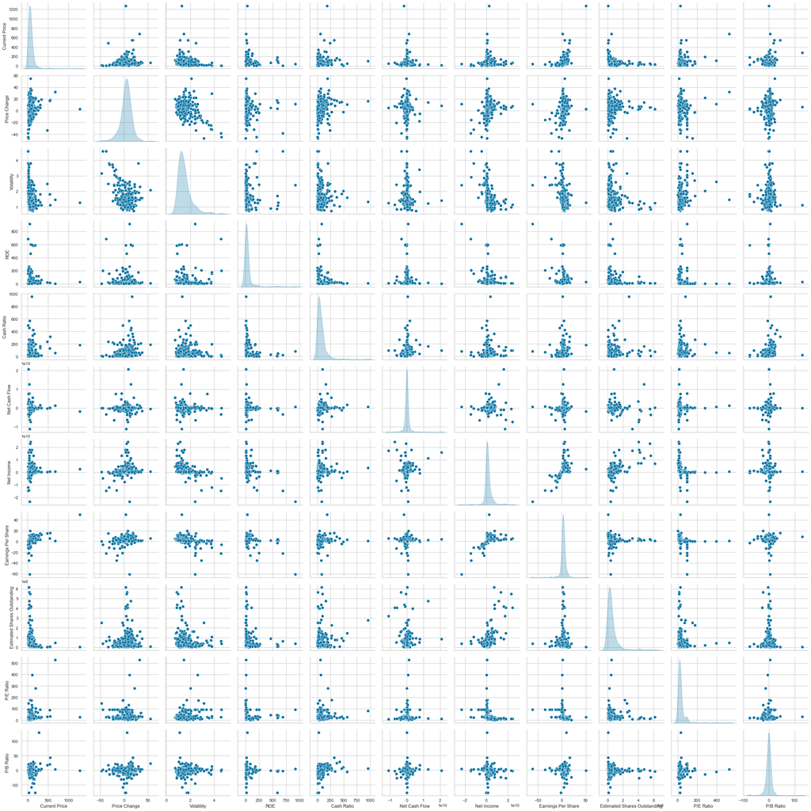

```python
#Big picture distributions
sns.pairplot(data=df[num_col], diag_kind="kde")
plt.show()
```

#### Stocks of which economic sector have seen the largest price increase?

```python
df.groupby("GICS Sector")["Price Change"].describe()
```

| GICS Sector | count | mean | std | min | 25% | 50% | 75% | max |
| --- | --- | --- | --- | --- | --- | --- | --- | --- |
| Consumer Discretionary | 40.0 | 5.846093 | 13.290771 | -33.131268 | 1.227730 | 3.543658 | 12.249013 | 34.803917 |
| Consumer Staples | 19.0 | 8.684750 | 8.795128 | -12.017268 | 5.426784 | 6.976738 | 12.605282 | 24.496225 |
| Energy | 30.0 | -10.228289 | 16.939222 | -47.129693 | -20.668060 | -9.244788 | 2.959008 | 17.341522 |
| Financials | 49.0 | 3.865406 | 6.024301 | -14.292764 | -0.361785 | 3.910301 | 7.696534 | 15.462833 |
| Health Care | 40.0 | 9.585652 | 9.848818 | -12.532337 | 1.528455 | 10.324402 | 16.775604 | 33.177346 |
| Industrials | 53.0 | 2.833127 | 9.922247 | -23.244191 | -2.797977 | 3.952561 | 10.105078 | 20.432767 |
| Information Technology | 33.0 | 7.217476 | 14.462923 | -23.790903 | -1.827858 | 7.496965 | 14.035095 | 55.051683 |
| Materials | 20.0 | 5.589738 | 15.283690 | -31.685166 | -1.306572 | 4.906245 | 15.450133 | 37.489677 |
| Real Estate | 27.0 | 6.205548 | 5.623694 | -13.067267 | 4.198144 | 7.578608 | 9.139503 | 15.573900 |
| Telecommunications Services | 5.0 | 6.956980 | 10.588878 | -2.301255 | 0.159232 | 5.942118 | 6.277303 | 24.707504 |
| Utilities | 24.0 | 0.803657 | 4.471067 | -8.230553 | -2.187929 | 1.281624 | 3.661202 | 8.596874 |

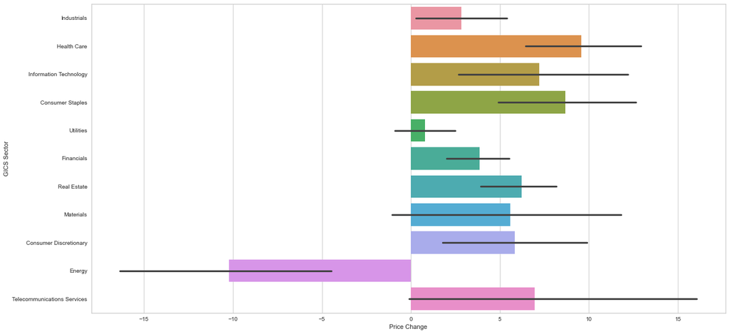

```python
plt.figure(figsize=(20, 10))
sns.barplot(data=df, y="GICS Sector", x="Price Change")
```

- Health Care stocks on average have seen the largest stock price increase over the last 13 weeks with an average $9.6

#### How does the average cash ratio vary across economic sectors?

```python
df.groupby("GICS Sector")["Cash Ratio"].describe()
```

| GICS Sector | count | mean | std | min | 25% | 50% | 75% | max |
| --- | --- | --- | --- | --- | --- | --- | --- | --- |
| Consumer Discretionary | 40.0 | 49.575000 | 69.208302 | 0.0 | 11.5 | 25.0 | 35.50 | 260.0 |
| Consumer Staples | 19.0 | 70.947368 | 125.832549 | 9.0 | 18.0 | 33.0 | 63.00 | 568.0 |
| Energy | 30.0 | 51.133333 | 55.939458 | 0.0 | 7.0 | 38.5 | 68.50 | 201.0 |
| Financials | 49.0 | 98.591837 | 17.907073 | 51.0 | 99.0 | 99.0 | 99.00 | 183.0 |
| Health Care | 40.0 | 103.775000 | 104.118150 | 3.0 | 41.5 | 70.0 | 128.25 | 425.0 |
| Industrials | 53.0 | 36.188679 | 29.127080 | 1.0 | 15.0 | 31.0 | 44.00 | 130.0 |
| Information Technology | 33.0 | 149.818182 | 174.231429 | 16.0 | 45.0 | 126.0 | 180.00 | 958.0 |
| Materials | 20.0 | 41.700000 | 50.396428 | 2.0 | 10.0 | 25.0 | 49.50 | 198.0 |
| Real Estate | 27.0 | 50.111111 | 28.250709 | 12.0 | 47.0 | 47.0 | 47.00 | 164.0 |
| Telecommunications Services | 5.0 | 117.000000 | 213.083317 | 3.0 | 11.0 | 14.0 | 61.00 | 496.0 |
| Utilities | 24.0 | 13.625000 | 17.277310 | 0.0 | 3.0 | 8.5 | 14.25 | 74.0 |

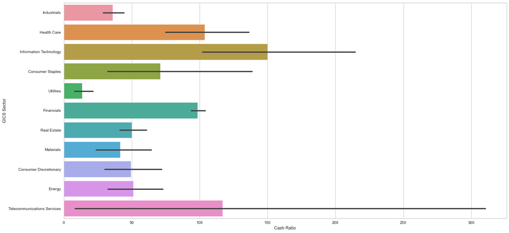

```python
plt.figure(figsize=(20, 10))
sns.barplot(data=df, y="GICS Sector", x="Cash Ratio")
```

- The information technology stocks have the highest average cash ratio across the economic sectors, followed by Telecommunications Services and Health Care.

#### P/E ratios can help determine the relative value of a company's shares as they signify the amount of money an investor is willing to invest in a single share of a company per dollar of its earnings. How does the P/E ratio vary, on average, across economic sectors?

```python
df.groupby("GICS Sector")["P/E Ratio"].describe()
```

| GICS Sector | count | mean | std | min | 25% | 50% | 75% | max |
| --- | --- | --- | --- | --- | --- | --- | --- | --- |
| Consumer Discretionary | 40.0 | 35.211613 | 80.902902 | 5.566284 | 15.459391 | 20.819876 | 25.887634 | 528.039074 |
| Consumer Staples | 19.0 | 25.521195 | 10.291193 | 9.986637 | 21.391092 | 24.070121 | 26.176366 | 48.412370 |
| Energy | 30.0 | 72.897709 | 42.144306 | 8.429600 | 28.407929 | 93.089287 | 93.089287 | 171.962965 |
| Financials | 49.0 | 16.023151 | 7.281892 | 4.304511 | 10.914049 | 14.276451 | 18.703854 | 38.721154 |
| Health Care | 40.0 | 41.135272 | 46.756416 | 8.180275 | 19.165522 | 27.967442 | 35.700025 | 280.514706 |
| Industrials | 53.0 | 18.259380 | 7.587633 | 2.935451 | 13.048485 | 17.334711 | 20.556076 | 41.199999 |
| Information Technology | 33.0 | 43.782546 | 70.242260 | 10.209198 | 18.249407 | 25.309524 | 31.040405 | 394.413783 |
| Materials | 20.0 | 24.585352 | 12.349729 | 9.033264 | 16.001852 | 22.811951 | 32.226881 | 57.210844 |
| Real Estate | 27.0 | 43.065585 | 22.799372 | 13.164179 | 28.294875 | 33.685393 | 48.266787 | 110.764709 |
| Telecommunications Services | 5.0 | 12.222578 | 4.210623 | 5.598352 | 10.552512 | 14.518987 | 14.518987 | 15.924051 |
| Utilities | 24.0 | 18.719412 | 5.143485 | 9.293155 | 16.909186 | 18.216489 | 19.510019 | 33.792080 |

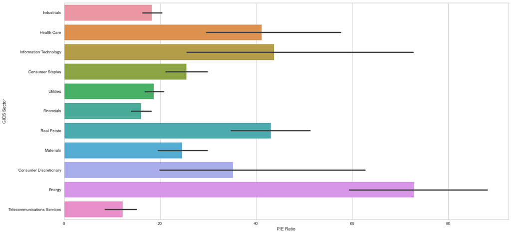

```python
plt.figure(figsize=(20, 10))
sns.barplot(data=df, y="GICS Sector", x="P/E Ratio")
```

- The highest P/E ratio average belongs to the Energy Sector at 72.89
- The next three highest P/E ratios belong to the Information Technology, Real Estate and Health Care Sectors.

#### Scaling numeric data to prepare for clustering

```python
# Scaling the data set before clustering
scaler = StandardScaler()
subset = df[num_col].copy()
subset_scaled = scaler.fit_transform(subset)
```

```python
# Creating a dataframe from the scaled data
subset_scaled_df = pd.DataFrame(subset_scaled, columns=subset.columns)

subset_scaled_df.head()
```

|  | Current Price | Price Change | Volatility | ROE | Cash Ratio | Net Cash Flow | Net Income | Earnings Per Share | Estimated Shares Outstanding | P/E Ratio | P/B Ratio |
| --- | --- | --- | --- | --- | --- | --- | --- | --- | --- | --- | --- |
| 0 | -0.393341 | 0.493950 | 0.272749 | 0.989601 | -0.210698 | -0.339355 | 1.554415 | 1.309399 | 0.107863 | -0.652487 | -0.506653 |
| 1 | -0.220837 | 0.355439 | 1.137045 | 0.937737 | 0.077269 | -0.002335 | 0.927628 | 0.056755 | 1.250274 | -0.311769 | -0.504205 |
| 2 | -0.367195 | 0.602479 | -0.427007 | -0.192905 | -0.033488 | 0.454058 | 0.744371 | 0.024831 | 1.098021 | -0.391502 | 0.094941 |
| 3 | 0.133567 | 0.825696 | -0.284802 | -0.317379 | 1.218059 | -0.152497 | -0.219816 | -0.230563 | -0.091622 | 0.947148 | 0.424333 |
| 4 | -0.260874 | -0.492636 | 0.296470 | -0.265515 | 2.237018 | 0.133564 | -0.202703 | -0.374982 | 1.978399 | 3.293307 | 0.199196 |

```
Number of Clusters: 1 	Average Distortion: 2.5425069919221697
Number of Clusters: 2 	Average Distortion: 2.384499097487295
Number of Clusters: 3 	Average Distortion: 2.2692367155390745
Number of Clusters: 4 	Average Distortion: 2.1770961257432995
Number of Clusters: 5 	Average Distortion: 2.140142891213095
Number of Clusters: 6 	Average Distortion: 2.116827259798435
Number of Clusters: 7 	Average Distortion: 2.0321372574873173
Number of Clusters: 8 	Average Distortion: 1.9899047212918002
```

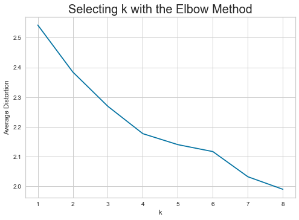

```python
clusters = range(1, 9)
meanDistortions = []

for k in clusters:
    model = KMeans(n_clusters=k)
    model.fit(subset_scaled_df)
    prediction = model.predict(subset_scaled_df)
    distortion = (
        sum(
            np.min(cdist(subset_scaled_df, model.cluster_centers_, "euclidean"), axis=1)
        )
        / subset_scaled_df.shape[0]
    )

    meanDistortions.append(distortion)

    print("Number of Clusters:", k, "\tAverage Distortion:", distortion)

plt.plot(clusters, meanDistortions, "bx-")
plt.xlabel("k")
plt.ylabel("Average Distortion")
plt.title("Selecting k with the Elbow Method", fontsize=20)
```

- Elbows at k=4, k=6, and k=7

#### Checking K values with Silhouette Score

```
For n_clusters = 2, silhouette score is 0.43969639509980457
For n_clusters = 3, silhouette score is 0.45494915445064915
For n_clusters = 4, silhouette score is 0.4634280755871751
For n_clusters = 5, silhouette score is 0.4166170771600757
For n_clusters = 6, silhouette score is 0.3863465606304045
For n_clusters = 7, silhouette score is 0.39290126833986105
For n_clusters = 8, silhouette score is 0.41476612263987034
For n_clusters = 9, silhouette score is 0.40224227420635367
```

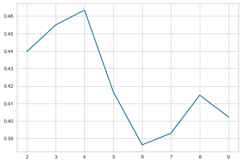

```python
# Using Silhouette Scores to verify best K value
sil_score = []
cluster_list = list(range(2, 10))
for n_clusters in cluster_list:
    clusterer = KMeans(n_clusters=n_clusters)
    preds = clusterer.fit_predict((subset_scaled_df))
    # centers = clusterer.cluster_centers_
    score = silhouette_score(subset_scaled_df, preds)
    sil_score.append(score)
    print("For n_clusters = {}, silhouette score is {}".format(n_clusters, score))

plt.plot(cluster_list, sil_score)
```

- Clear peak at k=4 and the silhouette score is the highest which indicates optimal K value for clustering

## K-means Clustering

- Silhoette and elbow methods indicate k value of 4 is optimal, 8 is also an option

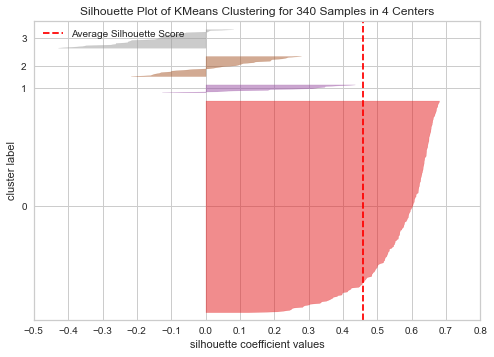

```python
# finding optimal no. of clusters with silhouette coefficients
visualizer = SilhouetteVisualizer(KMeans(4, random_state=1))
visualizer.fit(subset_scaled_df)
visualizer.show()
```

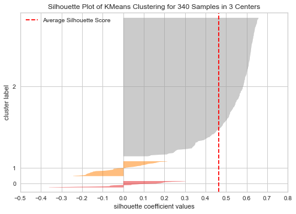

```python
# finding optimal no. of clusters with silhouette coefficients
visualizer = SilhouetteVisualizer(KMeans(3, random_state=1))
visualizer.fit(subset_scaled_df)
visualizer.show()
```

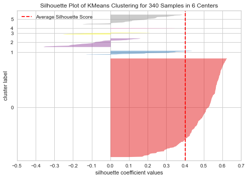

```python
# Checking other potential K values
# finding optimal no. of clusters with silhouette coefficients
visualizer = SilhouetteVisualizer(KMeans(6, random_state=1))
visualizer.fit(subset_scaled_df)
visualizer.show()
```

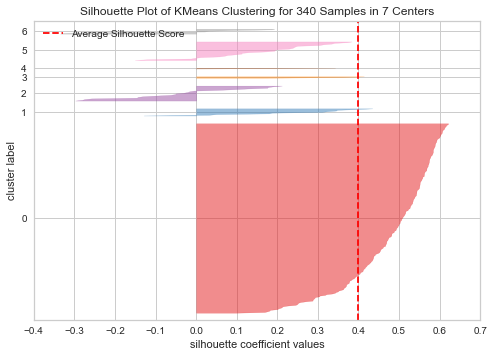

```python
# Checking other potential K values
# finding optimal no. of clusters with silhouette coefficients
visualizer = SilhouetteVisualizer(KMeans(7, random_state=1))
visualizer.fit(subset_scaled_df)
visualizer.show()
```

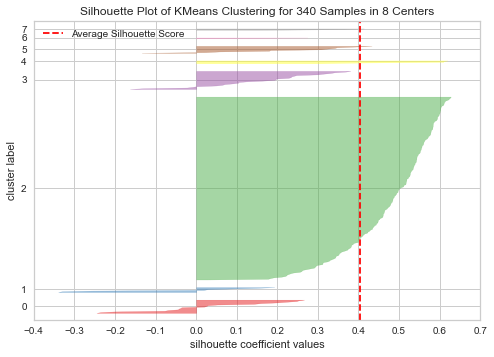

```python
# Checking other potential K values
# finding optimal no. of clusters with silhouette coefficients
visualizer = SilhouetteVisualizer(KMeans(8, random_state=1))
visualizer.fit(subset_scaled_df)
visualizer.show()
```

- We will proceed using a K value of 4 with potentiall using a different cluster if analysis does not produce sufficient insight

```python
kmeans = KMeans(n_clusters=4, random_state=0)
kmeans.fit(subset_scaled_df)
```

```
KMeans(n_clusters=4, random_state=0)
```

```python
# adding kmeans cluster labels to the original dataframe
df["K_means_segments"] = kmeans.labels_
subset_scaled_df["K_means_segments"] = kmeans.labels_
```

```python
#How many counts in each cluster
cluster_profile = df.groupby("K_means_segments").mean()
cluster_profile["count_in_each_segments"] = (
    df.groupby("K_means_segments")["Current Price"].count().values
)
```

```python
# let's display cluster profiles
cluster_profile.style.highlight_max(color="lightgreen", axis=0)
```

| K_means_segments | Current Price | Price Change | Volatility | ROE | Cash Ratio | Net Cash Flow | Net Income | Earnings Per Share | Estimated Shares Outstanding | P/E Ratio | P/B Ratio | count_in_each_segments |
| --- | --- | --- | --- | --- | --- | --- | --- | --- | --- | --- | --- | --- |
| 0 | 234.170932 | 13.400685 | 1.729989 | 25.600000 | 277.640000 | 1554926560.000000 | 1572611680.000000 | 6.045200 | 578316318.948800 | 74.960824 | 14.402452 | 25 |
| 1 | 38.099260 | -15.370329 | 2.910500 | 107.074074 | 50.037037 | -159428481.481481 | -3887457740.740741 | -9.473704 | 480398572.845926 | 90.619220 | 1.342067 | 27 |
| 2 | 50.517273 | 5.747586 | 1.130399 | 31.090909 | 75.909091 | -1072272727.272727 | 14833090909.090910 | 4.154545 | 4298826628.727273 | 14.803577 | -4.552119 | 11 |
| 3 | 72.399112 | 5.066225 | 1.388319 | 34.620939 | 53.000000 | -14046223.826715 | 1482212389.891697 | 3.621029 | 438533835.667184 | 23.843656 | -3.358948 | 277 |

- 4th cluster is the largest by far

#### Scaled data

```python
cluster_profile2 = subset_scaled_df.groupby("K_means_segments").mean()
cluster_profile2["count_in_each_segments"] = (
    subset_scaled_df.groupby("K_means_segments")["Current Price"].count().values
)
```

```python
# let's display cluster profiles
cluster_profile2.style.highlight_max(color="lightgreen", axis=0)
```

| K_means_segments | Current Price | Price Change | Volatility | ROE | Cash Ratio | Net Cash Flow | Net Income | Earnings Per Share | Estimated Shares Outstanding | P/E Ratio | P/B Ratio | count_in_each_segments |
| --- | --- | --- | --- | --- | --- | --- | --- | --- | --- | --- | --- | --- |
| 0 | 1.565799 | 0.777609 | 0.345241 | -0.145189 | 2.299485 | 0.771489 | 0.019883 | 0.496883 | 0.001525 | 0.956300 | 1.155908 | 25 |
| 1 | -0.436756 | -1.622242 | 2.342968 | 0.699929 | -0.221363 | -0.110608 | -1.367911 | -1.862300 | -0.114408 | 1.309894 | 0.219435 | 27 |
| 2 | -0.309926 | 0.139248 | -0.669418 | -0.088233 | 0.065186 | -0.580298 | 3.390319 | 0.209466 | 4.406556 | -0.402159 | -0.203198 | 11 |
| 3 | -0.086438 | 0.082414 | -0.232951 | -0.051617 | -0.188546 | -0.035803 | -0.003094 | 0.128361 | -0.163976 | -0.198018 | -0.117644 | 277 |

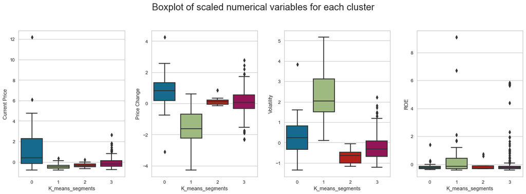

```python
fig, axes = plt.subplots(1, 4, figsize=(16, 6))
fig.suptitle("Boxplot of scaled numerical variables for each cluster", fontsize=20)
counter = 0
for ii in range(4):
    sns.boxplot(
        ax=axes[ii],
        y=subset_scaled_df[num_col[counter]],
        x=subset_scaled_df["K_means_segments"],
    )
    counter = counter + 1

fig.tight_layout(pad=2.0)
```

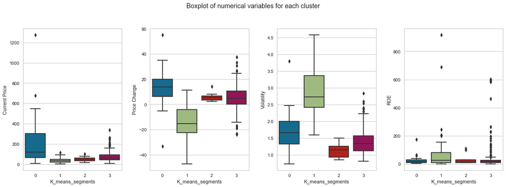

```python
fig, axes = plt.subplots(1, 4, figsize=(16, 6))
fig.suptitle("Boxplot of numerical variables for each cluster")
counter = 0
for ii in range(4):
    sns.boxplot(ax=axes[ii], y=df[num_col[counter]], x=df["K_means_segments"])
    counter = counter + 1

fig.tight_layout(pad=2.0)
```

#### Scaled Barplot

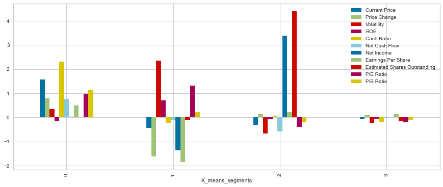

```python
subset_scaled_df.groupby("K_means_segments").mean().plot.bar(figsize=(15, 6))
```

#### Checking k=8

```python
# Make a copy so it does not affect anything
df1 = df.copy()
subset_scaled_df2 = subset_scaled_df.copy()
```

```python
kmeans2 = KMeans(n_clusters=8, random_state=0)
kmeans2.fit(subset_scaled_df2)
```

```
KMeans(random_state=0)
```

```python
# adding kmeans cluster labels to the original dataframe
df1["K_means_segments"] = kmeans2.labels_
subset_scaled_df2["K_means_segments"] = kmeans2.labels_
```

```python
# How many counts in each cluster
cluster_profile3 = df1.groupby("K_means_segments").mean()
cluster_profile3["count_in_each_segments"] = (
    df1.groupby("K_means_segments")["Current Price"].count().values
)
```

```python
# let's display cluster profiles
cluster_profile3.style.highlight_max(color="lightgreen", axis=0)
```

[output not shown]

[figure not shown]

```python
subset_scaled_df2.groupby("K_means_segments").mean().plot.bar(figsize=(15, 6))
```

- We will stick with 4 clusters as 8 clusters creates some with only a couple of companies

## Hierarchical Clustering

```python
# list of distance metrics
distance_metrics = ["euclidean", "chebyshev", "mahalanobis", "cityblock"]

# list of linkage methods
linkage_methods = ["single", "complete", "average", "weighted"]

high_cophenet_corr = 0
high_dm_lm = [0, 0]

for dm in distance_metrics:
    for lm in linkage_methods:
        Z = linkage(subset_scaled_df, metric=dm, method=lm)
        c, coph_dists = cophenet(Z, pdist(subset_scaled_df))
        print(
            "Cophenetic correlation for {} distance and {} linkage is {}.".format(
                dm.capitalize(), lm, c
            )
        )
        if high_cophenet_corr < c:
            high_cophenet_corr = c
            high_dm_lm[0] = dm
            high_dm_lm[1] = lm
```

```
Cophenetic correlation for Euclidean distance and single linkage is 0.9304469769832866.
Cophenetic correlation for Euclidean distance and complete linkage is 0.8559480642212798.
Cophenetic correlation for Euclidean distance and average linkage is 0.946403836884538.
Cophenetic correlation for Euclidean distance and weighted linkage is 0.7508819056084053.
Cophenetic correlation for Chebyshev distance and single linkage is 0.9161627445317929.
Cophenetic correlation for Chebyshev distance and complete linkage is 0.8225020941532581.
Cophenetic correlation for Chebyshev distance and average linkage is 0.9379218754329659.
Cophenetic correlation for Chebyshev distance and weighted linkage is 0.9153206618543515.
Cophenetic correlation for Mahalanobis distance and single linkage is 0.9348505176633235.
Cophenetic correlation for Mahalanobis distance and complete linkage is 0.6881861661402053.
Cophenetic correlation for Mahalanobis distance and average linkage is 0.9360657692078036.
Cophenetic correlation for Mahalanobis distance and weighted linkage is 0.8810701545336995.
Cophenetic correlation for Cityblock distance and single linkage is 0.938373245895409.
Cophenetic correlation for Cityblock distance and complete linkage is 0.8124007660644492.
Cophenetic correlation for Cityblock distance and average linkage is 0.9168123859372298.
Cophenetic correlation for Cityblock distance and weighted linkage is 0.866729262879581.
```

```python
# printing the combination of distance metric and linkage method with the highest cophenetic correlation
print(
    "Highest cophenetic correlation is {}, which is obtained with {} distance and {} linkage.".format(
        high_cophenet_corr, high_dm_lm[0].capitalize(), high_dm_lm[1]
    )
)
```

```
Highest cophenetic correlation is 0.946403836884538, which is obtained with Euclidean distance and average linkage.
```

```python
# list of linkage methods
linkage_methods = ["single", "complete", "average", "centroid", "ward", "weighted"]

high_cophenet_corr = 0
high_dm_lm = [0, 0]

for lm in linkage_methods:
    Z = linkage(subset_scaled_df, metric="euclidean", method=lm)
    c, coph_dists = cophenet(Z, pdist(subset_scaled_df))
    print("Cophenetic correlation for {} linkage is {}.".format(lm, c))
    if high_cophenet_corr < c:
        high_cophenet_corr = c
        high_dm_lm[0] = "euclidean"
        high_dm_lm[1] = lm
```

```
Cophenetic correlation for single linkage is 0.9304469769832866.
Cophenetic correlation for complete linkage is 0.8559480642212798.
Cophenetic correlation for average linkage is 0.946403836884538.
Cophenetic correlation for centroid linkage is 0.9494262703881243.
Cophenetic correlation for ward linkage is 0.7436374975239648.
Cophenetic correlation for weighted linkage is 0.7508819056084053.
```

```python
# printing the combination of distance metric and linkage method with the highest cophenetic correlation
print(
    "Highest cophenetic correlation is {}, which is obtained with {} linkage.".format(
        high_cophenet_corr, high_dm_lm[1]
    )
)
```

```
Highest cophenetic correlation is 0.9494262703881243, which is obtained with centroid linkage.
```

- Maximum cophentetic correlation is 0.9494262703881243, which is obtained with centroid linkage.

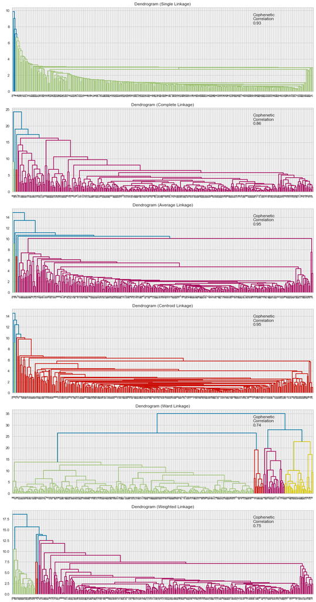

```python
# list of linkage methods
linkage_methods = ["single", "complete", "average", "centroid", "ward", "weighted"]

# lists to save results of cophenetic correlation calculation
compare_cols = ["Linkage", "Cophenetic Coefficient"]

# to create a subplot image
fig, axs = plt.subplots(len(linkage_methods), 1, figsize=(15, 30))

# We will enumerate through the list of linkage methods above
# For each linkage method, we will plot the dendrogram and calculate the cophenetic correlation
for i, method in enumerate(linkage_methods):
    Z = linkage(subset_scaled_df, metric="euclidean", method=method)

    dendrogram(Z, ax=axs[i])
    axs[i].set_title(f"Dendrogram ({method.capitalize()} Linkage)")

    coph_corr, coph_dist = cophenet(Z, pdist(subset_scaled_df))
    axs[i].annotate(
        f"Cophenetic\nCorrelation\n{coph_corr:0.2f}",
        (0.80, 0.80),
        xycoords="axes fraction",
    )
```

- Average and Centroid have the highest cophenetic correlations of 0.95
- Moving forward we will use Average linkage with 6 clusters as the Centroid method gets rather messy

### Cluster Profiling with Average Linkage and 6 Clusters

```python
HCmodel = AgglomerativeClustering(n_clusters=6, affinity="euclidean", linkage="average")
HCmodel.fit(subset_scaled_df)
```

```
AgglomerativeClustering(linkage='average', n_clusters=6)
```

```python
# Setup cluster columns in dataframe
subset_scaled_df["HC_Clusters"] = HCmodel.labels_
df["HC_Clusters"] = HCmodel.labels_
```

```python
cluster_profile = df.groupby("HC_Clusters").mean()
```

```python
cluster_profile["count_in_each_segments"] = (
    df.groupby("HC_Clusters")["Ticker Symbol"].count().values
)
```

```python
# let's see the Index Names of each company in the clusters

for cl in df["HC_Clusters"].unique():
    print(
        "The",
        df[df["HC_Clusters"] == cl]["Ticker Symbol"].nunique(),
        "Companies in cluster",
        cl,
        "are:",
    )
    print(df[df["HC_Clusters"] == cl]["Ticker Symbol"].unique())
    print("-" * 100, "\n")
```

```
The 333 Companies in cluster 0 are:
['AAL' 'ABBV' 'ABT' 'ADBE' 'ADI' 'ADM' 'AEE' 'AEP' 'AFL' 'AIG' 'AIV' 'AIZ'
 'AJG' 'AKAM' 'ALB' 'ALK' 'ALL' 'ALLE' 'ALXN' 'AMAT' 'AME' 'AMG' 'AMGN'
 'AMP' 'AMT' 'AMZN' 'AN' 'ANTM' 'AON' 'APC' 'APH' 'ARNC' 'ATVI' 'AVB'
 'AVGO' 'AWK' 'AXP' 'BA' 'BAX' 'BBT' 'BCR' 'BHI' 'BIIB' 'BK' 'BLL' 'BMY'
 'BSX' 'BWA' 'BXP' 'C' 'CAT' 'CB' 'CBG' 'CCI' 'CCL' 'CELG' 'CF' 'CFG'
 'CHD' 'CHRW' 'CHTR' 'CI' 'CINF' 'CL' 'CMA' 'CME' 'CMG' 'CMI' 'CMS' 'CNC'
 'CNP' 'COF' 'COG' 'COO' 'CSX' 'CTL' 'CTSH' 'CTXS' 'CVS' 'CVX' 'CXO' 'D'
 'DAL' 'DD' 'DE' 'DFS' 'DGX' 'DHR' 'DIS' 'DISCA' 'DISCK' 'DLPH' 'DLR'
 'DNB' 'DOV' 'DPS' 'DUK' 'DVA' 'DVN' 'EBAY' 'ECL' 'ED' 'EFX' 'EIX' 'EMN'
 'EOG' 'EQIX' 'EQR' 'EQT' 'ES' 'ESS' 'ETFC' 'ETN' 'ETR' 'EW' 'EXC' 'EXPD'
 'EXPE' 'EXR' 'F' 'FAST' 'FBHS' 'FCX' 'FE' 'FIS' 'FISV' 'FLIR' 'FLR' 'FLS'
 'FMC' 'FRT' 'FSLR' 'FTR' 'GD' 'GGP' 'GILD' 'GLW' 'GM' 'GPC' 'GRMN' 'GT'
 'GWW' 'HAL' 'HAS' 'HBAN' 'HCA' 'HCN' 'HCP' 'HES' 'HIG' 'HOG' 'HON' 'HPE'
 'HPQ' 'HRL' 'HSIC' 'HST' 'HSY' 'HUM' 'IBM' 'IDXX' 'IFF' 'IP' 'IPG' 'IRM'
 'ISRG' 'ITW' 'IVZ' 'JBHT' 'JEC' 'JNPR' 'JPM' 'KIM' 'KMB' 'KMI' 'KO' 'KSU'
 'LEG' 'LEN' 'LH' 'LKQ' 'LLL' 'LLY' 'LMT' 'LNT' 'LUK' 'LUV' 'LVLT' 'LYB'
 'MA' 'MAA' 'MAC' 'MAR' 'MAS' 'MAT' 'MCD' 'MCO' 'MDLZ' 'MET' 'MHK' 'MJN'
 'MKC' 'MLM' 'MMC' 'MMM' 'MNST' 'MO' 'MOS' 'MPC' 'MRK' 'MRO' 'MTB' 'MTD'
 'MUR' 'MYL' 'NAVI' 'NBL' 'NDAQ' 'NEE' 'NEM' 'NFLX' 'NFX' 'NLSN' 'NOV'
 'NSC' 'NTRS' 'NUE' 'NWL' 'O' 'OKE' 'OMC' 'ORLY' 'OXY' 'PBCT' 'PBI' 'PCAR'
 'PCG' 'PEG' 'PEP' 'PFE' 'PFG' 'PG' 'PGR' 'PHM' 'PM' 'PNC' 'PNR' 'PNW'
 'PPG' 'PPL' 'PRU' 'PSX' 'PWR' 'PX' 'PYPL' 'R' 'RCL' 'REGN' 'RHI' 'ROP'
 'RRC' 'RSG' 'SCG' 'SCHW' 'SE' 'SEE' 'SHW' 'SLG' 'SNI' 'SO' 'SPG' 'SPGI'
 'SRCL' 'SRE' 'STI' 'STT' 'SWKS' 'SWN' 'SYF' 'SYK' 'T' 'TAP' 'TDC' 'TGNA'
 'TMK' 'TMO' 'TRIP' 'TRV' 'TSCO' 'TSN' 'TSO' 'TSS' 'TXN' 'UAA' 'UAL' 'UDR'
 'UHS' 'UNH' 'UNM' 'UNP' 'UPS' 'UTX' 'VAR' 'VLO' 'VMC' 'VNO' 'VRSK' 'VRSN'
 'VRTX' 'VTR' 'VZ' 'WAT' 'WEC' 'WFC' 'WHR' 'WM' 'WMB' 'WU' 'WY' 'WYN'
 'WYNN' 'XEC' 'XEL' 'XL' 'XOM' 'XRAY' 'XRX' 'XYL' 'YHOO' 'YUM' 'ZBH'
 'ZION' 'ZTS']
----------------------------------------------------------------------------------------------------

The 1 Companies in cluster 5 are:
['ADS']
----------------------------------------------------------------------------------------------------

The 2 Companies in cluster 2 are:
['APA' 'CHK']
----------------------------------------------------------------------------------------------------

The 2 Companies in cluster 1 are:
['BAC' 'INTC']
----------------------------------------------------------------------------------------------------

The 1 Companies in cluster 3 are:
['FB']
----------------------------------------------------------------------------------------------------

The 1 Companies in cluster 4 are:
['PCLN']
----------------------------------------------------------------------------------------------------
```

- The clustering using Average linkage produces clusters that do not have much variability
- Cluster 0 dominates with the remaining 5 clusters only totaling 7 companies out of over 300
- Looking at the dendrograms for a method offering better variability and grouping the Ward Linkage method has good grouping albeit a lower cophenetic correlation.

### Cluster Profiling with Ward Linkage and 6 clusters

```python
# Reprocessing using Ward Linkage and 6 clusters
HCmodel = AgglomerativeClustering(n_clusters=6, affinity="euclidean", linkage="ward")
HCmodel.fit(subset_scaled_df)
```

```
AgglomerativeClustering(n_clusters=6)
```

```python
subset_scaled_df_hc = subset_scaled_df.copy()
subset_scaled_df_hc["HC_Clusters"] = HCmodel.labels_
df_hc = df.copy()
df_hc["HC_Clusters"] = HCmodel.labels_
```

```python
cluster_profile_hc = df_hc.groupby("HC_Clusters").mean()
```

```python
cluster_profile_hc["count_in_each_segments"] = (
    df_hc.groupby("HC_Clusters")["Ticker Symbol"].count().values
)
```

```python
# let's see the Index Names of each company in the clusters

for cl in df_hc["HC_Clusters"].unique():
    print(
        "The",
        df_hc[df_hc["HC_Clusters"] == cl]["Ticker Symbol"].nunique(),
        "Companies in cluster",
        cl,
        "are:",
    )
    print(df_hc[df_hc["HC_Clusters"] == cl]["Ticker Symbol"].unique())
    print("-" * 100, "\n")
```

```
The 273 Companies in cluster 1 are:
['AAL' 'ABBV' 'ABT' 'ADBE' 'ADM' 'AEE' 'AEP' 'AFL' 'AIG' 'AIV' 'AIZ' 'AJG'
 'AKAM' 'ALB' 'ALK' 'ALL' 'AMAT' 'AME' 'AMG' 'AMP' 'AMT' 'AN' 'ANTM' 'AON'
 'APH' 'ARNC' 'ATVI' 'AVB' 'AVGO' 'AWK' 'AXP' 'BA' 'BAX' 'BBT' 'BCR' 'BK'
 'BLL' 'BMY' 'BSX' 'BWA' 'BXP' 'CAT' 'CB' 'CBG' 'CCI' 'CCL' 'CF' 'CFG'
 'CHD' 'CHRW' 'CI' 'CINF' 'CMA' 'CME' 'CMI' 'CMS' 'CNC' 'CNP' 'COF' 'COO'
 'CSX' 'CTL' 'CTSH' 'CTXS' 'CVS' 'CVX' 'D' 'DAL' 'DD' 'DE' 'DFS' 'DGX'
 'DHR' 'DIS' 'DISCA' 'DISCK' 'DLPH' 'DLR' 'DNB' 'DOV' 'DPS' 'DUK' 'DVA'
 'EBAY' 'ECL' 'ED' 'EFX' 'EIX' 'EMN' 'EQR' 'ES' 'ESS' 'ETFC' 'ETN' 'ETR'
 'EXC' 'EXPD' 'EXPE' 'EXR' 'FAST' 'FBHS' 'FE' 'FIS' 'FISV' 'FLIR' 'FLR'
 'FLS' 'FMC' 'FRT' 'GD' 'GGP' 'GILD' 'GLW' 'GM' 'GPC' 'GRMN' 'GT' 'GWW'
 'HAS' 'HBAN' 'HCA' 'HCN' 'HCP' 'HIG' 'HOG' 'HON' 'HPQ' 'HRL' 'HSIC' 'HST'
 'HSY' 'HUM' 'IBM' 'IDXX' 'IFF' 'IP' 'IPG' 'IRM' 'ITW' 'IVZ' 'JBHT' 'JEC'
 'JNPR' 'KIM' 'KSU' 'LEG' 'LEN' 'LH' 'LKQ' 'LLL' 'LLY' 'LMT' 'LNT' 'LUK'
 'LUV' 'LVLT' 'LYB' 'MA' 'MAA' 'MAC' 'MAR' 'MAS' 'MAT' 'MCO' 'MDLZ' 'MET'
 'MHK' 'MJN' 'MKC' 'MLM' 'MMC' 'MMM' 'MO' 'MOS' 'MPC' 'MRK' 'MTB' 'MTD'
 'MYL' 'NAVI' 'NDAQ' 'NEE' 'NEM' 'NLSN' 'NSC' 'NTRS' 'NUE' 'NWL' 'O' 'OMC'
 'ORLY' 'PBCT' 'PBI' 'PCAR' 'PCG' 'PEG' 'PEP' 'PFG' 'PG' 'PGR' 'PHM' 'PM'
 'PNC' 'PNR' 'PNW' 'PPG' 'PPL' 'PRU' 'PSX' 'PX' 'PYPL' 'R' 'RCL' 'RHI'
 'ROP' 'RSG' 'SCG' 'SCHW' 'SE' 'SEE' 'SHW' 'SLG' 'SNI' 'SO' 'SPG' 'SRCL'
 'SRE' 'STI' 'STT' 'SWKS' 'SYF' 'SYK' 'TAP' 'TGNA' 'TMK' 'TMO' 'TRV'
 'TSCO' 'TSN' 'TSO' 'TSS' 'TXN' 'UAA' 'UAL' 'UDR' 'UHS' 'UNH' 'UNM' 'UNP'
 'UPS' 'UTX' 'VAR' 'VLO' 'VMC' 'VNO' 'VRSK' 'VRSN' 'VTR' 'WEC' 'WHR' 'WM'
 'WU' 'WY' 'WYN' 'XEL' 'XL' 'XRAY' 'XRX' 'XYL' 'YUM' 'ZBH' 'ZION' 'ZTS']
----------------------------------------------------------------------------------------------------

The 22 Companies in cluster 2 are:
['ADI' 'ADS' 'AMGN' 'BAC' 'BIIB' 'CELG' 'CMG' 'EQIX' 'EW' 'FB' 'FSLR'
 'FTR' 'INTC' 'ISRG' 'MCD' 'MNST' 'REGN' 'TRIP' 'VRTX' 'WAT' 'WYNN' 'YHOO']
----------------------------------------------------------------------------------------------------

The 7 Companies in cluster 5 are:
['ALLE' 'APA' 'CHK' 'CHTR' 'CL' 'KMB' 'SPGI']
----------------------------------------------------------------------------------------------------

The 4 Companies in cluster 0 are:
['ALXN' 'AMZN' 'NFLX' 'PCLN']
----------------------------------------------------------------------------------------------------

The 25 Companies in cluster 4 are:
['APC' 'BHI' 'COG' 'CXO' 'DVN' 'EOG' 'EQT' 'FCX' 'HAL' 'HES' 'HPE' 'KMI'
 'MRO' 'MUR' 'NBL' 'NFX' 'NOV' 'OKE' 'OXY' 'PWR' 'RRC' 'SWN' 'TDC' 'WMB'
 'XEC']
----------------------------------------------------------------------------------------------------

The 9 Companies in cluster 3 are:
['C' 'F' 'JPM' 'KO' 'PFE' 'T' 'VZ' 'WFC' 'XOM']
----------------------------------------------------------------------------------------------------
```

```python
# lets display cluster profile


cluster_profile_hc.style.highlight_max(color="lightgreen", axis=0)
```

| HC_Clusters | Current Price | Price Change | Volatility | ROE | Cash Ratio | Net Cash Flow | Net Income | Earnings Per Share | Estimated Shares Outstanding | P/E Ratio | P/B Ratio | count_in_each_segments |
| --- | --- | --- | --- | --- | --- | --- | --- | --- | --- | --- | --- | --- |
| 0 | 563.992491 | 17.235667 | 1.839399 | 10.250000 | 125.500000 | 105834000.000000 | 853500250.000000 | 13.085000 | 287806305.492500 | 307.105187 | -4.254889 | 4 |
| 1 | 71.846974 | 4.953643 | 1.392784 | 25.117216 | 53.831502 | 1197787.545788 | 1557673743.589744 | 3.691044 | 443918320.070366 | 23.583804 | -3.087957 | 273 |
| 2 | 168.776969 | 13.470771 | 1.716274 | 28.181818 | 294.409091 | 2004843181.818182 | 2187042363.636364 | 4.649091 | 800854767.052273 | 43.691770 | 16.272263 | 22 |
| 3 | 46.672222 | 5.166566 | 1.079367 | 25.000000 | 58.333333 | -3040666666.666667 | 14848444444.444445 | 3.435556 | 4564959946.222222 | 15.596051 | -6.354193 | 9 |
| 4 | 35.974801 | -16.181693 | 2.839136 | 51.400000 | 54.920000 | 214828360.000000 | -2701680000.000000 | -6.929600 | 494323223.557600 | 80.955889 | 2.246062 | 25 |
| 5 | 84.355716 | 3.854981 | 1.827670 | 633.571429 | 33.571429 | -568400000.000000 | -4968157142.857142 | -10.841429 | 398169036.442857 | 42.284541 | -11.589502 | 7 |

```python
df_hc["HC_Clusters"].value_counts()
```

```
1    273
4     25
2     22
3      9
5      7
0      4
Name: HC_Clusters, dtype: int64
```